# Shiny - Calendarios - Mapas

## Shiny

[figure not shown]

Shiny es un paquete de **R** que facilita la creación de aplicaciones web interactivas (apps) directamente desde R.

### Estructura de una aplicación

Las aplicaciones se escriben en un script sencillo con nombre **app.R**, el cual tiene dos componentes

- Un objeto de interfaz: ui()
- Una función del servidor: server()

El objeto **ui()** controla la apariencia de la aplicación, mientras que la función **server()** contiene las instrucciones para construir la aplicación.

```r
library(shiny)

ui <-
server <-
shinyApp(ui = ui, server = server)
```

### Crear un aplicación Shiny

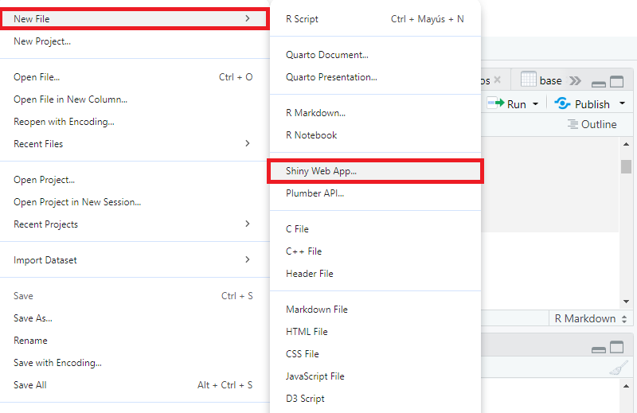

Una vez abierto **Shiny Web app** aparecerá la siguiente ventana, en donde debemos especifivar la ruta en dónde se creará la carpeta que contendrá el proyecto.

[figure not shown]

### Ejemplos

Descargar la carpeta **Ejemplo_histograma**. Con ‘setwd()’ setear la ruta en donde se encuentra la carpeta. Por último correr el siguiente script.

```r
library(shiny)

runApp("Ejemplo_histograma")
```

Otra manera de ejecutarla, es abrir el script **App.R** en el editor de RStudio, en donde aparecerá el botón *Run App* en la parte superior derecha del editor.

Se pueden crear aplicaciones copiando y modificando aplicaciones e Shiny ya existentes. La galería [Shiny](https://shiny.posit.co/r/gallery/) contiene una amplia variedad de apicaciones con sus correspondientes códigos. O también se pueden utilizar los ejemplos predefinidos de Shiny que se indican a continuación:

```r
runExample("01_hello")      # a histogram
runExample("02_text")       # tables and data frames
runExample("03_reactivity") # a reactive expression
runExample("04_mpg")        # global variables
runExample("05_sliders")    # slider bars
runExample("06_tabsets")    # tabbed panels
runExample("07_widgets")    # help text and submit buttons
runExample("08_html")       # Shiny app built from HTML
runExample("09_upload")     # file upload wizard
runExample("10_download")   # file download wizard
runExample("11_timer")      # an automated timer
```

Por defecto, las aplicaciones Shiny se muestran en modo “normal”, es decir, sin el script. Para que se muestre junto a la aplicación el script, se debe establecer en modo “showcase” de la siguiente manera:

```r
runApp("01_hello", display.mode = "showcase")
```

O también se puede ver el directorio dónde se sitúan los archivos con los códigos de estos ejemplos. Para ello se debe ejecutar la siguiente función;

```r
system.file("examples", package="shiny")
```

### Interfaz ui.R

Shiny usa la función **fluidPage()** para crear una pantalla que se ajusta automáticamente a las dimensiones de la ventana del navegador. El diseño de la interfaz de usuario consiste en colocar elementos en esta función.

Los dos elementos más comunes que se adicionan a **fluidPage()** son titlePanel() y sidebarLayout().  
sidebarLayout() tiene dos argumentos:

- La función sidebarPanel(): panel lateral izquierdo
- La función mainPanel(): panel lateral derecho, en donde en general se muestra los resultados.

Se puede mover hacia el lado derecho dando el argumento opcional **position = “right”**.

### Controles Widgets

Son elementos web con los que el usuario puede interactuar, proporcionando una forma de intercambiar valores u opciones.

En la galería de [Widgets](https://shiny.posit.co/r/gallery/widgets/widget-gallery/)

Para agregar un widget() a la aplicación, se puede hacer en sidebarPanel() o en mainPanel() dentro del objeto ui.

Los primeros dos argumentos para cada widget son:

- Nombre para el widget: el usuario no verá este nombre, pero es necesario en el código, para poder acedera él.
- Etiqueta: será el nombre que el usuario podrá ver en la aplicación

### Salida reactiva

En una salida reactiva se puede agregar cualquier salida de R, la cual responde automáticamente cuando un usuario cambia el valor de un widget.

Se pueden crear resultados reactivos en un proceso de dos pasos:

- Agregar un objeto R a la ui().
- Indicar a Shiny cómo construir el objeto en la función server(). El objeto será reactivo al enlazarlo con un widget.

### Server

Esto se debe hacer en la función server(), la cual crea un objeto de nombre output que contiene todo el código necesario para actualizar los objetos R de la aplicación.

Cada objeto R necesita tener su propia entrada, cuyo nombre debe coincidir con el elemento reactivo que se creó en la ui().

## Calendario

Con el paquete **calendR** se pueden crear mapas de calor con calendarios mensuales o anuales. Se debe especificar un año, un mes, establecer gradient = TRUE y cargar los datos.

Los colores se pueden personalizar con el argumento **low.col** (color para el valor más bajo) y **special.col** (color para el valor más alto).

Hay que tener en cuenta que los datos deben ser de la misma longitud que el número de días del mes o del año, según se utilice.

- Ejemplo:

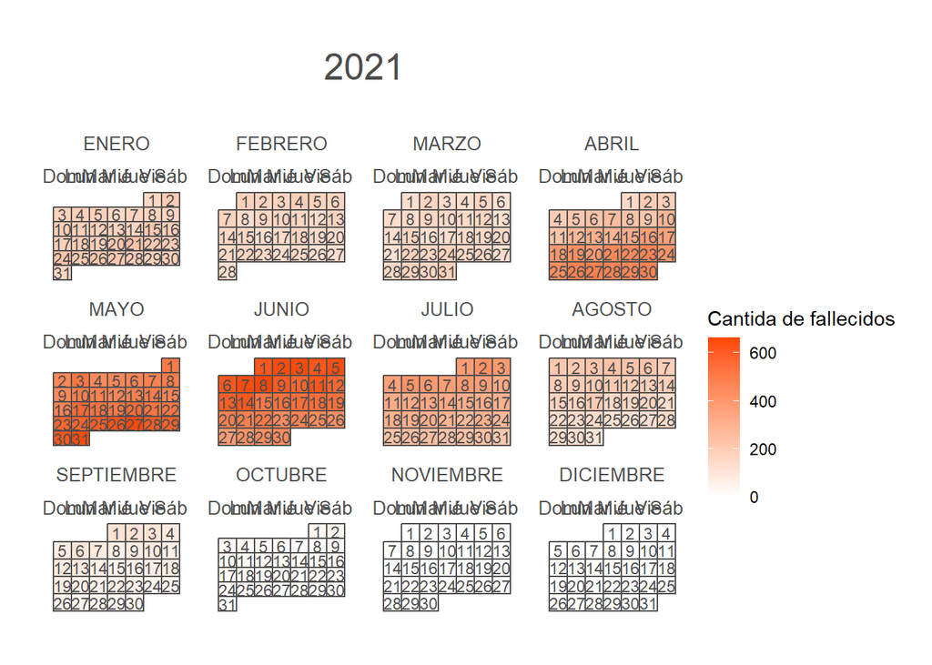

```r
library(calendR)

covid <- read_excel("fallecidos de covid.xlsx")

covid_2021 <- covid %>% filter(dia > "2020-12-31")

calendR(year = 2021,
        special.days = covid_2021$total,
        gradient = TRUE,
        low.col = "white",
        special.col = "#FF4600",
        legend.pos = "right",
        legend.title = "Cantida de fallecidos")
```

[Galerìa de calendarios](https://r-coder.com/calendar-plot-r/)

### googleVis

El paquete googleVis proporciona una interfaz entre R y las herramientas de gráficos de Google. El paquete proporciona interfaces para, entre otras, las siguientes funciones:

- Gráfico geográfico
- Gráfico de dispersión
- Gráfico de barras
- Histograma
- Gráfico de burbujas
- Gráfico de velas
- Gráfico de calendario

Permite a los usuarios crear páginas web con gráficos interactivos basados en marcos de datos de R. Si bien utiliza las herramientas de gráficos de Google, los datos se mantienen locales y no se suben a Google

```r
library(googleVis)

plotdata <- gvisCalendar(data=covid,
                         datevar="dia",
                         numvar="total",
                         options=list(
                           title="Fallecimientos por Coronavirus en Argentina",
                           calendar="{cellSize:10,
                                 yearLabel:{fontSize:20, color:'#444444'},
                                 focusedCellColor:{stroke:'red'}}",
                           width=700, height=400),
                         chartid="Calendar")
plot(plotdata)
```

## Mapas

Una de las formas para realizar mapas es utilizando el paquete **ggplot2**. Para el tratamiento de datos espaciales se puede utilizar el paquete **sf** .

Antes de crear un gráfico con ggplot2, es necesario tener en la sesión de R los datos necesarios para generar el mapa. Por lo tanto se deben descargar las coordenadas de los políginos del mapa a graficar. Por lo tanto, es necesario buscar en la web los archivos que tengan las coordenadas requeridas, que en general son **.json**.

- Ejemplo

En este ejemplo descargamos las coordenadas de la Ciudad de Buenos Aires y graficamos el mapa

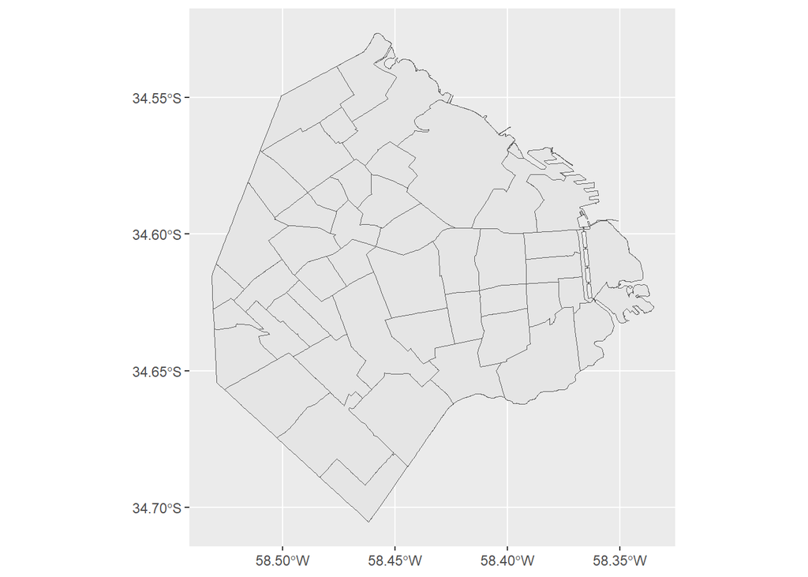

```r
library(sf)

map_data <- st_read("https://cdn.buenosaires.gob.ar/datosabiertos/datasets/ministerio-de-educacion/barrios/barrios.geojson")
ggplot() +
  geom_sf(data = map_data)
```

Haciendo uso del mapa graficamos las ubicaciones de las casas que se encuentran en venta de la base de datos **properati**

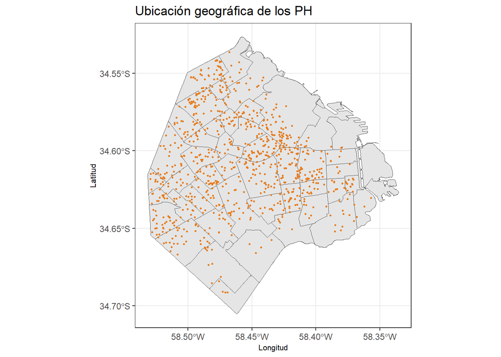

```r
datos <- read_excel("Properati2.xlsx")

df <- datos %>%
  select(-c(start_date, end_date, created_on, title, description))

df <- df %>%
  filter(
    l1 == "Argentina",
    l2 == "Capital Federal",
    property_type == "PH",
    operation_type == "Venta")

barrio_data <- df %>% filter(lon >= -35 & lon <= -33 & lat >= -58.55 & lat <= -58.30)

ggplot() +
  geom_sf(data = map_data) +  # Plot the map
  geom_point(data = barrio_data, aes(x = lat, y = lon), color = "#E67E22", size = 0.5) +
  labs(title = "Ubicación geográfica de los PH", x = "Longitud", y = "Latitud") +
  theme_bw() +
  xlab("Longitud") +
  ylab("Latitud") +
  theme(axis.title.x = element_text(size = 8),
        axis.title.y = element_text(size = 8))
```

Ahora vamos a graficar el precio promedio por barrio:

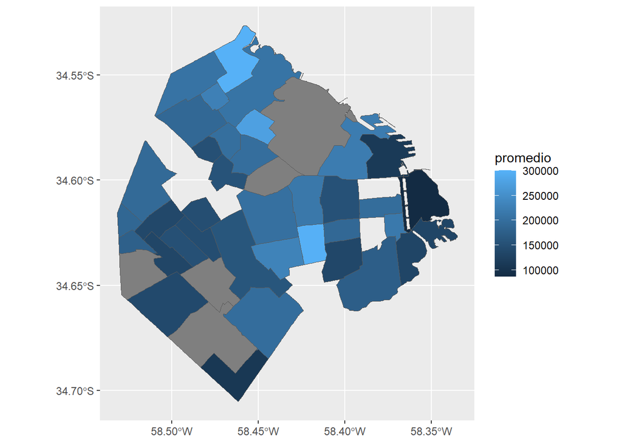

```r
precio_promedio <- datos %>% group_by(l3) %>% summarise(promedio = mean(price)) %>%
                   rename(nombre = l3)

prec_promedio_capital <- inner_join(map_data, precio_promedio, by = "nombre")

ggplot(data = prec_promedio_capital) +
  geom_sf(aes(fill = promedio))
```

Utilizamos la librería **plotly**

```r
library(plotly)

grafico_inter <- ggplot(data = prec_promedio_capital) +
  geom_sf(aes(fill = promedio))

ggplotly(grafico_inter)
```

[interactive chart not shown]

## Ejercicio

```r
runApp("Nombres_Argentina")
```